# Lecture 5 Code

Alex Hoagland

2022-08-11

```r
################################################################################
# I like to include several additional notes in the header of my files here:
#
# Last modified: 8/11/2022
#
### PURPOSE:
  # Lecture 5 code and output file
#
### NOTES:
  # - uses the Tidyverse package and Dplyr
################################################################################


### 0. Load the packages we will need for this file ####
library(tidyverse) # load the installed package for each new session of R
library(broom)
library(readxl) # Read in data
library(modelsummary) # For making regression tables
library(causaldata) # Useful toy data sets
library(here) # Helpful in working with directories and projects
library(vtable) # For making balance tables
library(MatchIt) # Main matching package

set.seed(03262020) # Setting the seed helps to make random number generators give us the same numbers across machines
################################################################################
```

## What if I don’t match?

Suppose that we are interested in the effect of having health insurance on total health expenditures. Let’s load some sample data (don’t forget to have your project set up so that `here()` knows where to look).

```r
mydata <- read_xlsx(here("HealthExpenses.xlsx"))

    # first, simple regression -- what is effect of insurance on expenses?
    m1 <- lm(expenses ~ coverage,data=mydata)
    msummary(list(m1),
             vcov=c("robust"),
             stars=c('*' = .1, '**' = .05, '***' = .01))
```

|  | Model 1 |
| --- | --- |
| (Intercept) | 10274.015*** |
|  | (356.494) |
| coverage | 6231.280*** |
|  | (649.538) |
| Num.Obs. | 1340 |
| R2 | 0.066 |
| R2 Adj. | 0.065 |
| AIC | 28913.6 |
| BIC | 28929.2 |
| Log.Lik. | −14453.789 |
| F | 92.033 |
| RMSE | 11701.48 |
| Std.Errors | Robust |

* p < 0.1, ** p < 0.05, *** p < 0.01

This would suggest that having coverage *increases* expenses! But there are important differences in treated and control groups that might make this an artifact of **selection**

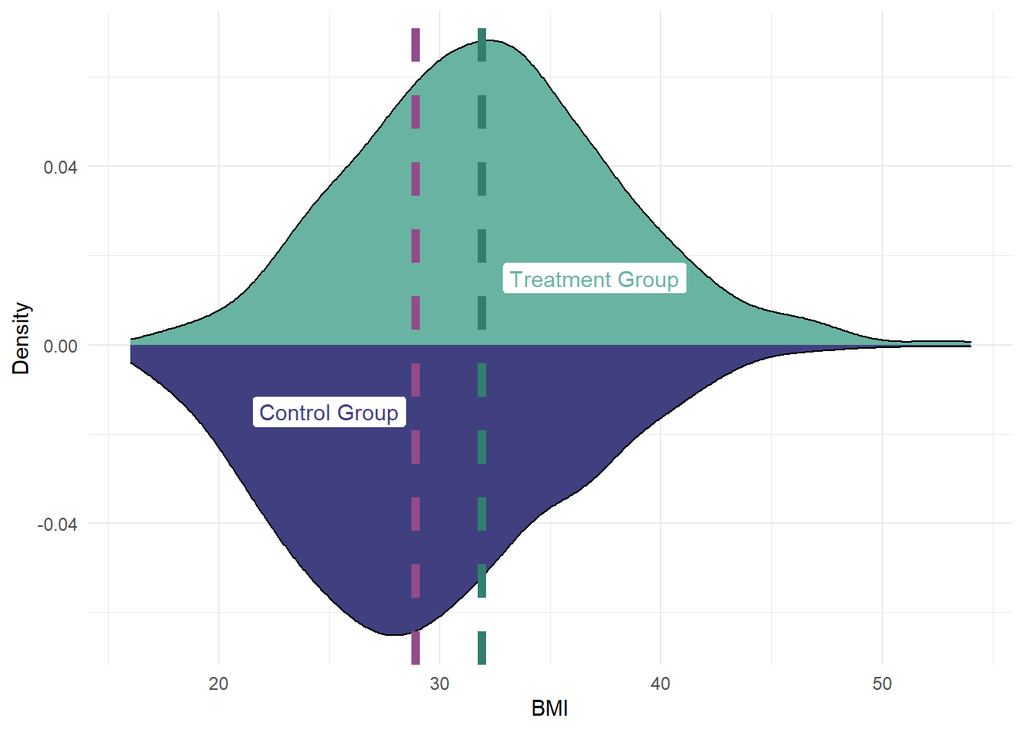

```r
    mydata %>%
      mutate(BMI1 = ifelse(coverage == 1,bmi,NA),
             BMI2 = ifelse(coverage == 0,bmi,NA)) %>%
      ggplot(aes(x=bmi) ) +
      geom_density( aes(x = BMI1, y = ..density..), fill="#69b3a2") +
      geom_label( aes(x=37, y=0.015, label="Treatment Group"), color="#69b3a2") +
      geom_density( aes(x = BMI2, y = -..density..), fill= "#404080") +
      geom_label( aes(x=25, y=-0.015, label="Control Group"), color="#404080") +
      theme_minimal() +
      geom_vline(xintercept = median(mydata[which(mydata$coverage==1),]$bmi),color = "#337E6E",size=2,linetype="dashed") +
      geom_vline(xintercept = median(mydata[which(mydata$coverage==0),]$bmi),color = "#944B8C",size=2,linetype="dashed") +
      labs(x="BMI",y="Density")
```

```r
    # Summary table of all baseline outcomes across groups
sumtable(data=mydata,group="coverage",
           vars=c("age","sex","bmi","children","smoker","expenses"),
           digits=2,group.test=T)
```

Summary Statistics

| coverage Variable | 0 N | 0 Mean | 0 SD | 1 N | 1 Mean | 1 SD | Test |
| --- | --- | --- | --- | --- | --- | --- | --- |
| age | 695 | 38.81 | 14.37 | 645 | 39.65 | 13.73 | F=1.196 |
| sex | 695 |  |  | 645 |  |  | X2=0.053 |
| … female | 347 | 50% |  | 317 | 49% |  |  |
| … male | 348 | 50% |  | 328 | 51% |  |  |
| bmi | 695 | 29.33 | 6.03 | 645 | 32.13 | 5.9 | F=73.254*** |
| children | 695 | 0.89 | 1.09 | 645 | 1.31 | 1.28 | F=41.79*** |
| smoker | 695 | 0.09 | 0.29 | 645 | 0.32 | 0.47 | F=116.843*** |
| expenses | 695 | 10274.01 | 9391.43 | 645 | 16505.29 | 13778.92 | F=94.725*** |

Statistical significance markers: * p<0.1; ** p<0.05; *** p<0.01

## Subclassification example

Let’s start with matching based on a single variable: patient BMI. We first create bins of BMI that take it from a lot of variation into just a few categories (quantiles) from the disribution.

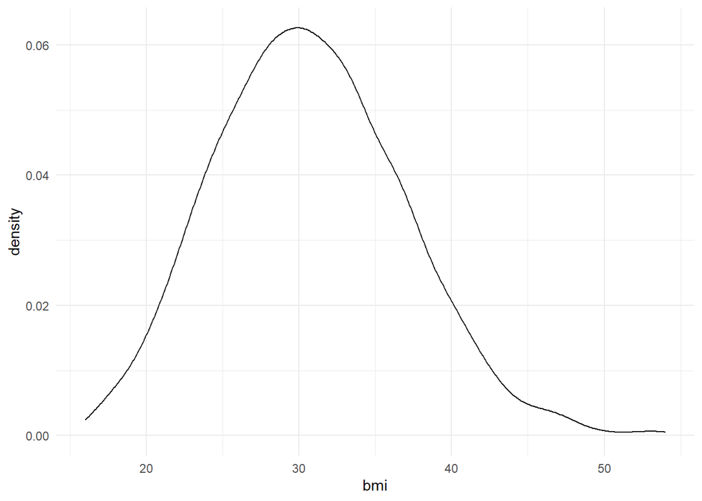

```r
ggplot(mydata,aes(x=bmi)) + geom_density() + theme_minimal() # Lots of variation in BMI
```

```r
# First, create bins of BMI values by quintiles
myquints <- unname(quantile(mydata$bmi,probs=c(0,.2,.4,.6,.8,1),na.rm=T))
mydata <- mydata %>% mutate(bin = ifelse(bmi >= myquints[1] & bmi < myquints[2],1,
                                   ifelse(bmi >= myquints[2] & bmi < myquints[3],2,
                                    ifelse(bmi >= myquints[3] & bmi < myquints[4],3,
                                     ifelse(bmi >= myquints[4] & bmi < myquints[5],4,5)))))
```

In each bin, we then construct the differences in expenses between the insured and uninsured. This rests on the assumption that within each bin, there is no (less) selection between insurance status. We then weight these differences by the relative size of each group.

```r
# For each bin, construct the difference in expenses by insurance category
bin_means <- mydata %>% group_by(bin,coverage) %>% summarize(expenses = mean(expenses)) %>%
    # Creates bin/group means
group_by(bin) %>% summarize(diff = expenses[2] - expenses[1])
```

[output not shown]

```r
# Create bins based on control group (uninsured)
obs = nrow(mydata %>% filter(coverage == 0))

wt1 <- mydata %>%
  filter(bin == 1 & coverage == 0) %>%
  nrow(.)/obs

wt2 <- mydata %>%
  filter(bin == 2 & coverage == 0) %>%
  nrow(.)/obs

wt3 <- mydata %>%
  filter(bin == 3 & coverage == 0) %>%
  nrow(.)/obs

wt4 <- mydata %>%
  filter(bin == 4 & coverage == 0) %>%
  nrow(.)/obs

wt5 <- mydata %>%
  filter(bin == 5 & coverage == 0) %>%
  nrow(.)/obs

bin_means[1,2]*wt1 + bin_means[2,2]*wt2 + bin_means[3,2]*wt3 + bin_means[4,2]*wt4 + bin_means[5,2]*wt5
```

```
##       diff
## 1 5474.693
```

### On your own: subclassification packages

In case you are curious, there are helpful packages for subclassification matching. See this chunk below for an example

```r
  # Do this with package stratamatch (https://cran.r-project.org/web/packages/stratamatch/vignettes/Intro_to_stratamatch.html)
  library(stratamatch)
  library(optmatch) # Used for matching stratified data

  m.strat <- manual_stratify(data=mydata,coverage ~ bin)
  summary(m.strat)
```

```
## Number of strata: 5
##
##  Min size: 261   Max size: 273
##
## Strata with Potential Issues: 0
```

```r
  m.strat$analysis_set # Analysis data
```

```
## # A tibble: 1,340 × 10
##      age sex      bmi children smoker region    expenses coverage   bin stratum
##    <dbl> <chr>  <dbl>    <dbl>  <dbl> <chr>        <dbl>    <dbl> <dbl>   <int>
##  1    19 female  27.9        0      1 southwest   16885.        0     2       2
##  2    18 male    33.8        1      0 southeast    1726.        0     4       4
##  3    28 male    33          3      0 southeast    4449.        1     4       4
##  4    33 male    22.7        0      0 northwest   21984.        0     1       1
##  5    32 male    28.9        0      0 northwest    3867.        0     3       3
##  6    31 female  25.7        0      0 southeast    3757.        0     2       2
##  7    46 female  33.4        1      0 southeast    8241.        1     4       4
##  8    37 female  27.7        3      0 northwest    7282.        1     2       2
##  9    37 male    29.8        2      0 northeast    6406.        1     3       3
## 10    60 female  25.8        0      0 northwest   28923.        0     2       2
## # … with 1,330 more rows
```

```r
  m.strat$issue_table # Any issues with strata
```

```
## # A tibble: 5 × 6
##   Stratum Treat Control Total Control_Proportion Potential_Issues
##     <int> <dbl>   <int> <int>              <dbl> <chr>
## 1       1    79     182   261              0.697 none
## 2       2   109     161   270              0.596 none
## 3       3   138     135   273              0.495 none
## 4       4   156     109   265              0.411 none
## 5       5   163     108   271              0.399 none
```

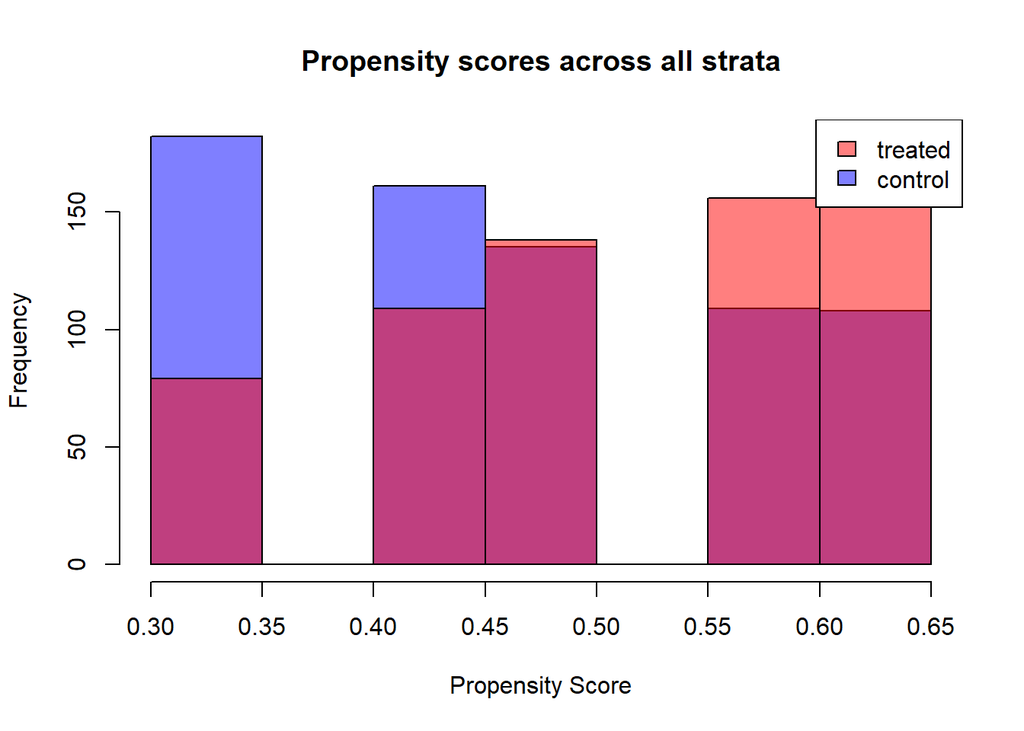

```r
  plot(m.strat, type = "hist", propensity = coverage ~ bin) # Look at propensity scores
```

```r
  mymatch <- strata_match(m.strat, coverage ~ bin, k = 1) # Match the data
```

```
## Fitting propensity model: coverage ~ bin
```

```r
  summary(mymatch)
```

```
## Structure of matched sets:
## 1:0 1:1 0:1
## 105 540 155
## Effective Sample Size:  540
## (equivalent number of matched pairs).
```

```r
  matched_data <- m.strat$analysis_set
  matched_data$match <- as.character(mymatch)
  matched_data %>% filter(!is.na(match)) %>% group_by(match) %>%
    arrange(match,coverage) %>%
    summarise(diff = expenses[2]-expenses[1]) %>%
    ungroup() %>% summarize(mean = mean(diff)) # Matched differences are $5559, close to the method above
```

```
## # A tibble: 1 × 1
##    mean
##   <dbl>
## 1 5559.
```

```r
  # We can add multiple variables
  m.strat <- manual_stratify(data=mydata,coverage ~ bin + smoker + children)
  summary(m.strat)
```

```
## Number of strata: 53
##
##  Min size: 1     Max size: 99
##
## Strata with Potential Issues: 49
```

```r
  m.strat$analysis_set
```

```
## # A tibble: 1,340 × 10
##      age sex      bmi children smoker region    expenses coverage   bin stratum
##    <dbl> <chr>  <dbl>    <dbl>  <dbl> <chr>        <dbl>    <dbl> <dbl>   <int>
##  1    19 female  27.9        0      1 southwest   16885.        0     2      18
##  2    18 male    33.8        1      0 southeast    1726.        0     4      34
##  3    28 male    33          3      0 southeast    4449.        1     4      36
##  4    33 male    22.7        0      0 northwest   21984.        0     1       1
##  5    32 male    28.9        0      0 northwest    3867.        0     3      23
##  6    31 female  25.7        0      0 southeast    3757.        0     2      12
##  7    46 female  33.4        1      0 southeast    8241.        1     4      34
##  8    37 female  27.7        3      0 northwest    7282.        1     2      15
##  9    37 male    29.8        2      0 northeast    6406.        1     3      25
## 10    60 female  25.8        0      0 northwest   28923.        0     2      12
## # … with 1,330 more rows
```

```r
  m.strat$issue_table
```

```
## # A tibble: 53 × 6
##    Stratum Treat Control Total Control_Proportion Potential_Issues
##      <int> <dbl>   <int> <int>              <dbl> <chr>
##  1       1    11      83    94              0.883 Small treat:control ratio
##  2       2    10      35    45              0.778 Too few samples
##  3       3    10      28    38              0.737 Too few samples
##  4       4     4      16    20              0.8   Too few samples
##  5       5     0       1     1              1     Too few samples; Small treat:…
##  6       6     4       1     5              0.2   Too few samples
##  7       7    14      10    24              0.417 Too few samples
##  8       8     6       3     9              0.333 Too few samples
##  9       9    10       4    14              0.286 Too few samples
## 10      10     9       1    10              0.1   Too few samples; Small contro…
## # … with 43 more rows
```

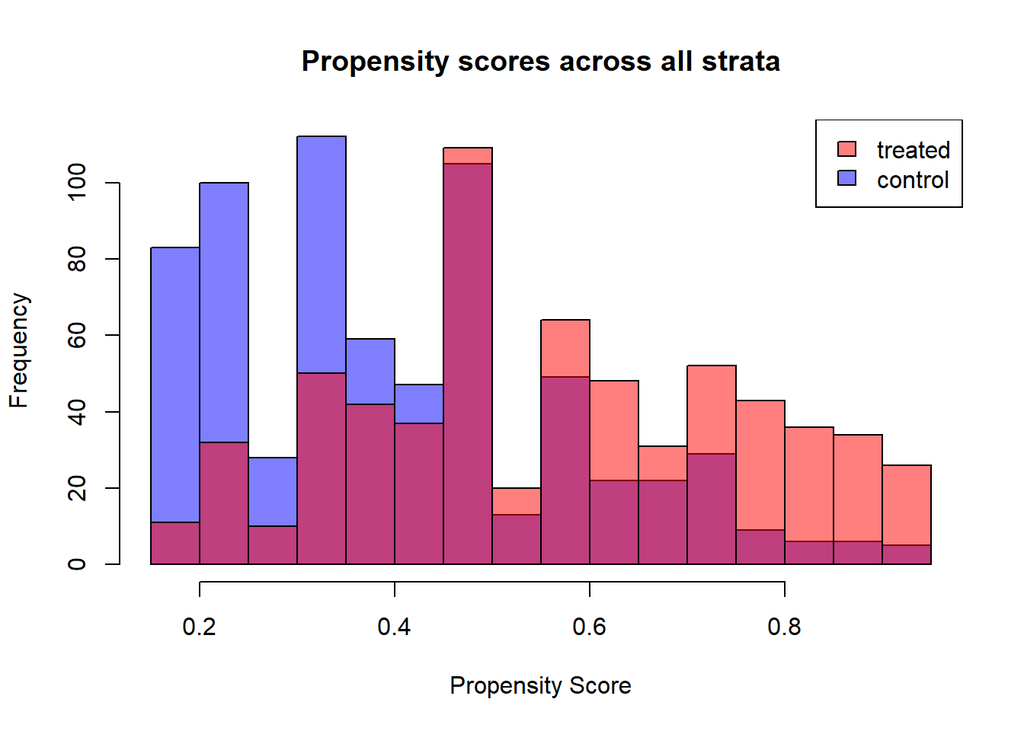

```r
  plot(m.strat, type = "hist", propensity = coverage ~ bin + smoker + children)
```

```r
  mymatch <- strata_match(m.strat, coverage ~ bin + smoker + children, k = 1) # Match the data
```

```
## Fitting propensity model: coverage ~ bin + smoker + children
```

```r
  summary(mymatch)
```

```
## Structure of matched sets:
## 1:0 1:1 0:1
## 204 441 254
## Effective Sample Size:  441
## (equivalent number of matched pairs).
```

```r
  matched_data <- m.strat$analysis_set
  matched_data$match <- as.character(mymatch)
  matched_data %>% filter(!is.na(match)) %>% group_by(match) %>%
    arrange(match,coverage) %>%
    summarise(diff = expenses[2]-expenses[1]) %>%
    ungroup() %>% summarize(mean = mean(diff)) # Now, matched differences go all the way down to -$45.8!
```

```
## # A tibble: 1 × 1
##    mean
##   <dbl>
## 1 -45.8
```

## Exact matching: Multiple Variables

Let’s expand beyond just BMI to include multiple variables (for now, just throw in the number of children in a household and if the enrollee is a smoker). First, we’ll look at exact matches only.

```r
treated <- mydata %>% filter(coverage == 1)
control <- mydata %>% filter(coverage == 0)
matched_data <- inner_join(treated,control,by=c('bmi','children','smoker'))
matched_data %>% mutate(diff = expenses.x-expenses.y) %>%
  group_by(bmi,children,smoker) %>% # Create one average per cell
  summarize(diff = mean(diff)) %>%
  ungroup() %>% # Now overall average
  summarize(diff = mean(diff)) # Estimated effect of insurance: -$269
```

```
## # A tibble: 1 × 1
##    diff
##   <dbl>
## 1 -269.
```

Now, the estimated effect of insurance has dropped to a $269 **decrease** in expenditures. But notice how much our sample size has been reduced!

We can get around this a little bit by not doing exact matching on a continuous variable (BMI) – let’s discretize it.

```r
matched_data <- inner_join(treated,control,by=c('bin','children','smoker'))
matched_data %>% mutate(diff = expenses.x-expenses.y) %>%
  group_by(bin,children,smoker) %>% # Create one average per cell
  summarize(diff = mean(diff)) %>%
  ungroup() %>% # Now overall average
  summarize(diff = mean(diff)) # Estimated effect of insurance: +$127
```

```
## # A tibble: 1 × 1
##    diff
##   <dbl>
## 1  127.
```

This isn’t much better in terms of sample size. Even with only three variables to match on, we are severely restricting our sample.

## Nearest Neighbor Matching

So let’s expand the criteria to nearest neighbor matching. We will match on a larger range of covariates now: * Enrollee age * Enrollee sex * Enrollee BMI * # of children * Smoker status * Region of residence

```r
mydata <- mydata %>% mutate(region_ne = ifelse(region == "northeast",1,0),
                            region_nw = ifelse(region == "northwest",1,0),
                            region_se = ifelse(region == "southeast",1,0),
                                # Create 3 dummy variables for the 4 regions
                            female = (ifelse(sex == "female",1,0)))

mymatches_nn <- matchit(coverage ~ age + female + bmi + children + smoker + region_ne + region_nw + region_se,
                     data=mydata,
                     method='nearest', # Matching method -- see ?matchit
                     distance='scaled_euclidean', # metric for distance
                     replace=TRUE, # do we use replacements in matches?
                     ratio=10, # how many matches are we looking for?
                     verbose=TRUE) # print output of package process
```

```
## Nearest neighbor matching...
## Calculating matching weights... Done.
```

```r
summary(mymatches_nn) # Look at new balance and sample size
```

```
##
## Call:
## matchit(formula = coverage ~ age + female + bmi + children +
##     smoker + region_ne + region_nw + region_se, data = mydata,
##     method = "nearest", distance = "scaled_euclidean", replace = TRUE,
##     ratio = 10, verbose = TRUE)
##
## Summary of Balance for All Data:
##           Means Treated Means Control Std. Mean Diff. Var. Ratio eCDF Mean
## age             39.6481       38.8072          0.0613     0.9116    0.0217
## female           0.4915        0.4993         -0.0156          .    0.0078
## bmi             32.1274       29.3337          0.4733     0.9572    0.0983
## children         1.3116        0.8921          0.3270     1.3852    0.0699
## smoker           0.3240        0.0950          0.4894          .    0.2291
## region_ne        0.2171        0.2662         -0.1192          .    0.0491
## region_nw        0.2450        0.2417          0.0075          .    0.0032
## region_se        0.2930        0.2518          0.0906          .    0.0412
##           eCDF Max
## age         0.0605
## female      0.0078
## bmi         0.2173
## children    0.1441
## smoker      0.2291
## region_ne   0.0491
## region_nw   0.0032
## region_se   0.0412
##
##
## Summary of Balance for Matched Data:
##           Means Treated Means Control Std. Mean Diff. Var. Ratio eCDF Mean
## age             39.6481       39.8285         -0.0131     1.0117    0.0076
## female           0.4915        0.4938         -0.0047          .    0.0023
## bmi             32.1274       31.0551          0.1817     1.2694    0.0374
## children         1.3116        1.0515          0.2027     1.3843    0.0434
## smoker           0.3240        0.2660          0.1239          .    0.0580
## region_ne        0.2171        0.2265         -0.0229          .    0.0095
## region_nw        0.2450        0.2406          0.0101          .    0.0043
## region_se        0.2930        0.2966         -0.0078          .    0.0036
##           eCDF Max Std. Pair Dist.
## age         0.0251          0.5427
## female      0.0023          0.1200
## bmi         0.1037          0.5820
## children    0.0843          0.4277
## smoker      0.0580          0.1239
## region_ne   0.0095          0.0350
## region_nw   0.0043          0.0209
## region_se   0.0036          0.0399
##
## Sample Sizes:
##               Control Treated
## All            695.       645
## Matched (ESS)  411.47     645
## Matched        673.       645
## Unmatched       22.         0
## Discarded        0.         0
```

```r
# View(mymatches_nn) # Look at objects returned if you want
```

Now that we have matched the data, we can estimate our model just as a difference in means:

```r
regdata_nn <- match.data(mymatches_nn)
nn_match <- lm(expenses ~ coverage,
               data = regdata_nn,
               weights=weights)
msummary(list("OLS"=m1, "Nearest Neighbor"=nn_match),
         vcov=c(~region,~region),
         stars=c('*' = .1, '**' = .05, '***' = .01))
```

|  | OLS | Nearest Neighbor |
| --- | --- | --- |
| (Intercept) | 10274.015*** | 14476.134*** |
|  | (464.144) | (1334.096) |
| coverage | 6231.280*** | 2029.161** |
|  | (487.611) | (889.258) |
| Num.Obs. | 1340 | 1318 |
| R2 | 0.066 | 0.006 |
| R2 Adj. | 0.065 | 0.005 |
| AIC | 28913.6 | 28961.1 |
| BIC | 28929.2 | 28976.6 |
| Log.Lik. | −14453.789 | −14477.546 |
| RMSE | 11701.48 | 12125.23 |
| Std.Errors | by: region | by: region |

* p < 0.1, ** p < 0.05, *** p < 0.01

Now, coverage is associated with an increase of $2,029.

## Propensity score matching

Finally, how might we implement propensity score matching in our scenario? We can use the same package (which is very versatile)

```r
mymatches_psm <- matchit(coverage ~ age + female + bmi + children + smoker + region_ne + region_nw + region_se, # Matching regression
                     data=mydata,
                     method='nearest', # Matching method -- see ?matchit
                     distance='glm', # generalized linear model for propensity
                     replace=TRUE, # do we use replacements in matches?
                     verbose=TRUE) # print output of package process
```

```
## Estimating propensity scores...
## Nearest neighbor matching...
## Calculating matching weights... Done.
```

```r
summary(mymatches_psm) # Look at new balance and sample size
```

```
##
## Call:
## matchit(formula = coverage ~ age + female + bmi + children +
##     smoker + region_ne + region_nw + region_se, data = mydata,
##     method = "nearest", distance = "glm", replace = TRUE, verbose = TRUE)
##
## Summary of Balance for All Data:
##           Means Treated Means Control Std. Mean Diff. Var. Ratio eCDF Mean
## distance         0.5672        0.4017          0.8402     1.2608    0.2349
## age             39.6481       38.8072          0.0613     0.9116    0.0217
## female           0.4915        0.4993         -0.0156          .    0.0078
## bmi             32.1274       29.3337          0.4733     0.9572    0.0983
## children         1.3116        0.8921          0.3270     1.3852    0.0699
## smoker           0.3240        0.0950          0.4894          .    0.2291
## region_ne        0.2171        0.2662         -0.1192          .    0.0491
## region_nw        0.2450        0.2417          0.0075          .    0.0032
## region_se        0.2930        0.2518          0.0906          .    0.0412
##           eCDF Max
## distance    0.3391
## age         0.0605
## female      0.0078
## bmi         0.2173
## children    0.1441
## smoker      0.2291
## region_ne   0.0491
## region_nw   0.0032
## region_se   0.0412
##
##
## Summary of Balance for Matched Data:
##           Means Treated Means Control Std. Mean Diff. Var. Ratio eCDF Mean
## distance         0.5672        0.5670          0.0012     1.0004    0.0014
## age             39.6481       40.4744         -0.0602     0.9199    0.0223
## female           0.4915        0.4915          0.0000          .    0.0000
## bmi             32.1274       32.8871         -0.1287     0.8492    0.0233
## children         1.3116        1.3504         -0.0302     1.0748    0.0147
## smoker           0.3240        0.2713          0.1126          .    0.0527
## region_ne        0.2171        0.2279         -0.0263          .    0.0109
## region_nw        0.2450        0.2698         -0.0577          .    0.0248
## region_se        0.2930        0.2884          0.0102          .    0.0047
##           eCDF Max Std. Pair Dist.
## distance    0.0171          0.0063
## age         0.0620          1.1661
## female      0.0000          0.4775
## bmi         0.0915          0.9243
## children    0.0372          0.9098
## smoker      0.0527          0.3909
## region_ne   0.0109          0.8086
## region_nw   0.0248          0.8868
## region_se   0.0047          0.8891
##
## Sample Sizes:
##               Control Treated
## All            695.       645
## Matched (ESS)  185.81     645
## Matched        308.       645
## Unmatched      387.         0
## Discarded        0.         0
```

When using propensity score matching, we need to make sure that our **common support assumption** holds in practice, so that we are truly (starting to) match(ing) in an appropriate way. We can test this visually:

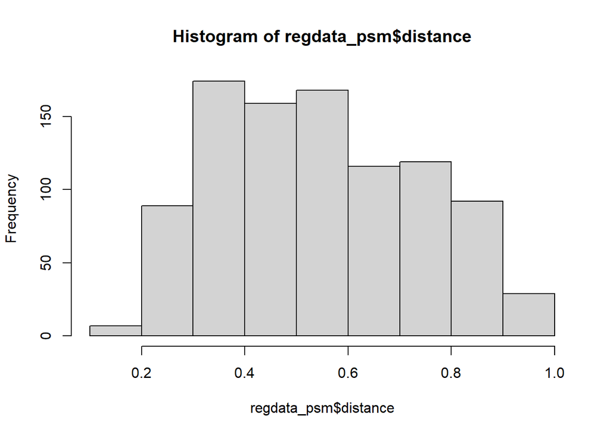

```r
regdata_psm <- match.data(mymatches_psm)
hist(regdata_psm$distance) # Look at overall distribution of propensity scores
```

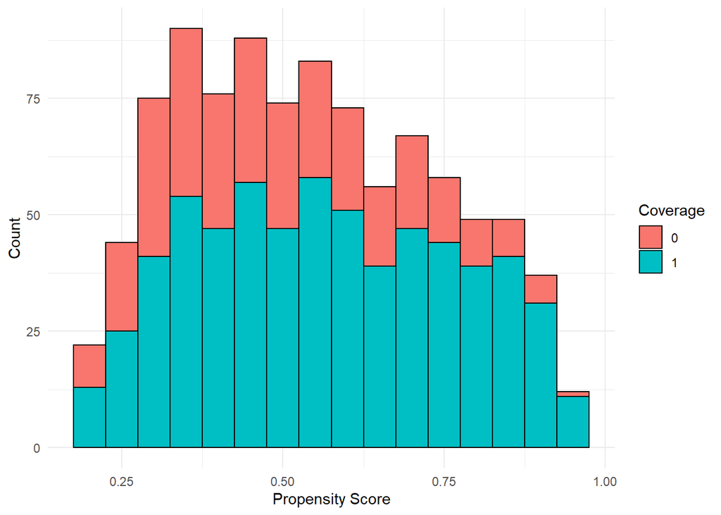

```r
# Test common support assumption
ggplot(regdata_psm,aes(x=distance, fill = factor(coverage))) +
  geom_histogram(binwidth = .05,color='black') +
  theme_minimal() +
  labs(x="Propensity Score", y="Count",fill="Coverage")
```

It looks like our common support assumption won’t be a problem here. Hence, we can run our regression:

```r
ps_match <- lm(expenses ~ coverage,
               data = regdata_psm,
               weights=1/distance)
msummary(list("OLS"=m1, "Nearest Neighbor"=nn_match, "Propensity Score"=ps_match),
         stars=c('*' = .1, '**' = .05, '***' = .01))
```

|  | OLS | Nearest Neighbor | Propensity Score |
| --- | --- | --- | --- |
| (Intercept) | 10274.015*** | 14476.134*** | 10757.148*** |
|  | (444.194) | (506.591) | (608.588) |
| coverage | 6231.280*** | 2029.161*** | 2623.267*** |
|  | (640.244) | (724.162) | (756.672) |
| Num.Obs. | 1340 | 1318 | 953 |
| R2 | 0.066 | 0.006 | 0.012 |
| R2 Adj. | 0.065 | 0.005 | 0.011 |
| AIC | 28913.6 | 28961.1 | 20546.3 |
| BIC | 28929.2 | 28976.6 | 20560.9 |
| Log.Lik. | −14453.789 | −14477.546 | −10270.141 |
| F | 94.725 | 7.852 | 12.019 |
| RMSE | 11701.48 | 12125.23 | 13350.21 |

* p < 0.1, ** p < 0.05, *** p < 0.01

## Matching Best Practices

Here are some code chunks for best practices, including: * Making a balance table * Testing common support (copied from above) * Trimming low-quality matches (shown here for PSM matching)

```r
# Balance table
sumtable(data=mydata,group="coverage",group.test=TRUE,title="Unmatched Sample")
```

Unmatched Sample

| coverage Variable | 0 N | 0 Mean | 0 SD | 1 N | 1 Mean | 1 SD | Test |
| --- | --- | --- | --- | --- | --- | --- | --- |
| age | 695 | 38.807 | 14.375 | 645 | 39.648 | 13.725 | F=1.196 |
| sex | 695 |  |  | 645 |  |  | X2=0.053 |
| … female | 347 | 49.9% |  | 317 | 49.1% |  |  |
| … male | 348 | 50.1% |  | 328 | 50.9% |  |  |
| bmi | 695 | 29.334 | 6.033 | 645 | 32.127 | 5.902 | F=73.254*** |
| children | 695 | 0.892 | 1.09 | 645 | 1.312 | 1.283 | F=41.79*** |
| smoker | 695 | 0.095 | 0.293 | 645 | 0.324 | 0.468 | F=116.843*** |
| region | 695 |  |  | 645 |  |  | X2=5.467 |
| … northeast | 185 | 26.6% |  | 140 | 21.7% |  |  |
| … northwest | 168 | 24.2% |  | 158 | 24.5% |  |  |
| … southeast | 175 | 25.2% |  | 189 | 29.3% |  |  |
| … southwest | 167 | 24% |  | 158 | 24.5% |  |  |
| expenses | 695 | 10274.015 | 9391.435 | 645 | 16505.295 | 13778.921 | F=94.725*** |
| bin | 695 | 2.712 | 1.406 | 645 | 3.333 | 1.343 | F=68.148*** |
| region_ne | 695 | 0.266 | 0.442 | 645 | 0.217 | 0.413 | F=4.404** |
| region_nw | 695 | 0.242 | 0.428 | 645 | 0.245 | 0.43 | F=0.019 |
| region_se | 695 | 0.252 | 0.434 | 645 | 0.293 | 0.456 | F=2.875* |
| female | 695 | 0.499 | 0.5 | 645 | 0.491 | 0.5 | F=0.081 |

Statistical significance markers: * p<0.1; ** p<0.05; *** p<0.01

```r
sumtable(data=regdata_psm,group="coverage",group.test=TRUE,title="Matched Sample",
         group.weights="weights")
```

Matched Sample

| coverage Variable | 0 N | 0 Wt. Mean | 0 Wt. SD | 1 N | 1 Wt. Mean | 1 Wt. SD | Test |
| --- | --- | --- | --- | --- | --- | --- | --- |
| age | 308 | 40.474 | 14.295 | 645 | 39.648 | 13.725 | F=0.736 |
| sex | 308 |  |  | 645 |  |  |  |
| … female | 160 | 49.1% |  | 317 | 49.1% |  |  |
| … male | 148 | 50.9% |  | 328 | 50.9% |  |  |
| bmi | 308 | 32.887 | 6.398 | 645 | 32.127 | 5.902 | F=3.269* |
| children | 308 | 1.35 | 1.236 | 645 | 1.312 | 1.283 | F=0.195 |
| smoker | 308 | 0.271 | 0.445 | 645 | 0.324 | 0.468 | F=2.725* |
| region | 308 |  |  | 645 |  |  |  |
| … northeast | 81 | 22.8% |  | 140 | 21.7% |  |  |
| … northwest | 72 | 27% |  | 158 | 24.5% |  |  |
| … southeast | 83 | 28.8% |  | 189 | 29.3% |  |  |
| … southwest | 72 | 21.4% |  | 158 | 24.5% |  |  |
| expenses | 308 | 15938.502 | 13945.624 | 645 | 16505.295 | 13778.921 | F=0.35 |
| bin | 308 | 3.443 | 1.395 | 645 | 3.333 | 1.343 | F=1.366 |
| region_ne | 308 | 0.228 | 0.42 | 645 | 0.217 | 0.413 | F=0.143 |
| region_nw | 308 | 0.27 | 0.445 | 645 | 0.245 | 0.43 | F=0.678 |
| region_se | 308 | 0.288 | 0.454 | 645 | 0.293 | 0.456 | F=0.022 |
| female | 308 | 0.491 | 0.501 | 645 | 0.491 | 0.5 | F=0 |
| distance | 308 | 0.567 | 0.197 | 645 | 0.567 | 0.197 | F=0 |

Statistical significance markers: * p<0.1; ** p<0.05; *** p<0.01

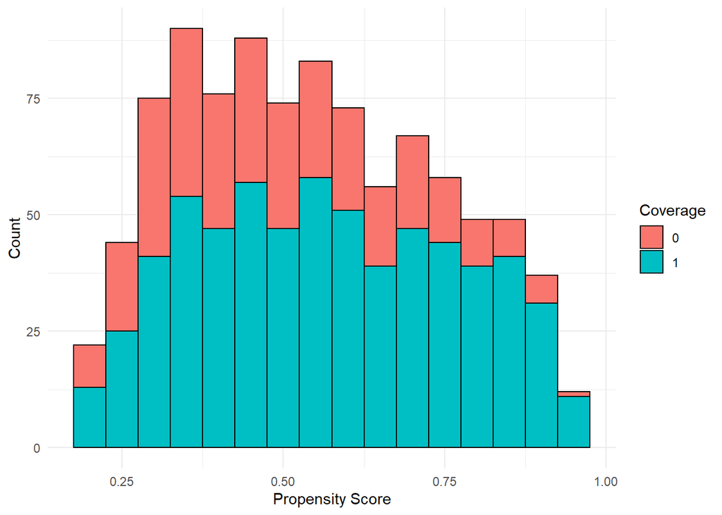

```r
# TODO: add a better sumtable here


# Common support (copied from above)
ggplot(regdata_psm,aes(x=distance, fill = factor(coverage))) +
  geom_histogram(binwidth = .05,color='black') +
  theme_minimal() +
  labs(x="Propensity Score", y="Count",fill="Coverage")
```

```r
# Trim observations with high/low propensity scores
ps_match_trim <- lm(expenses ~ coverage, # + age + female + bmi +children + smoker + region_ne + region_nw + region_se,
               data = regdata_psm[which(regdata_psm$distance>.05 & regdata_psm$distance<.95),],
               weights=1/distance)
msummary(list("OLS"=m1, "Nearest Neighbor"=nn_match, "Propensity Score"=ps_match, "Trimmed Propensity Score"=ps_match_trim),
         stars=c('*' = .1, '**' = .05, '***' = .01))
```

|  | OLS | Nearest Neighbor | Propensity Score | Trimmed Propensity Score |
| --- | --- | --- | --- | --- |
| (Intercept) | 10274.015*** | 14476.134*** | 10757.148*** | 10757.148*** |
|  | (444.194) | (506.591) | (608.588) | (606.654) |
| coverage | 6231.280*** | 2029.161*** | 2623.267*** | 2572.490*** |
|  | (640.244) | (724.162) | (756.672) | (754.479) |
| Num.Obs. | 1340 | 1318 | 953 | 951 |
| R2 | 0.066 | 0.006 | 0.012 | 0.012 |
| R2 Adj. | 0.065 | 0.005 | 0.011 | 0.011 |
| AIC | 28913.6 | 28961.1 | 20546.3 | 20495.8 |
| BIC | 28929.2 | 28976.6 | 20560.9 | 20510.4 |
| Log.Lik. | −14453.789 | −14477.546 | −10270.141 | −10244.920 |
| F | 94.725 | 7.852 | 12.019 | 11.626 |
| RMSE | 11701.48 | 12125.23 | 13350.21 | 13291.65 |

* p < 0.1, ** p < 0.05, *** p < 0.01